# Calibration of the TRIDENT trial to a population-based cohort in Scotland.

Dr Alice Hosking, Dr Katie Harris, Prof Rustam Al-Shahi Salman, Prof William Whiteley, Prof David McAllister

2026-11-10

## 1 Introduction

### 1.1 Purpose and scope of this document

This is a brief report of the results of calibration of the TRIDENT trial to a population-based inception cohort. The aim of this study is to calibrate the effect of a low-dose triple pill antihypertensive medication in people with ICH from the TRIDENT trial to a population-based cohort in Lothian, Scotland.

The outcomes are:

## 2 Methods

### 2.1 Time period definitions

We calibrate at two time points, 18 months ($T_1$) and end of follow up (approx 6 years, $T_2$). The time period from start of follow-up to $T_1$ is $\tau_1$. The time period from $T_1$ to $T_2$ is $\tau_2$.

### 2.2 Strata for analysis

Following inspection of the overlap between LATCH and TRIDENT, the split is as follows: TRIDENT is split into four strata: Male <65 years, Female <65 years, Male 65 years and over, Female 65 years and over. LATCH is split into eight strata: Male <65 years, Female <65 years, Male 65-75 years, Female 65-75 years,Male 75-85 years, Female 75-85 years,Male 85 years and over, Female 85 years and over.

### 2.4 Event rates in LATCH

The event rate is defined as:

$$\lambda_u=\text{rate in
untreated}$$
We define $n_s$ as the number of people in each stratum, and $m_s$ as the number of events per stratum.

$$\lambda_u=\frac{m_s}{\text{Total follow
up time for stratum}}$$
.

As we are assuming an exponential distribution, we can calculate the standard error directly:

$$SE(ln(\lambda_u))=
\frac{1}{\sqrt{m_s}}$$

We then simulate a normally distributed sample for the event rates.

### 2.5 Calibrated RR and CIs for each stratum

For each age/sex stratum and for each time period, we combine the rate in the untreated and the hazard ratio from the trial to obtain a risk ratio.

Recall:

$$\lambda_u=\text{rate in
untreated}$$

Multiply untreated rates by hazard ratios ($HR$) to get treated event rates in each time period:
$$\lambda_{treat1} = \lambda_u
\times HR_1$$
$$\lambda_{treat2} =
\lambda_u \times HR_2$$

We then transform these to risks for each stratum:
$$R_{untreated} = 1 -
exp{(-\lambda_u(\tau_1+\tau_2)})$$

and

$$R_{treated} = 1 -
exp{(-(\lambda_{treat1} \tau_1 + \lambda_{treat2} \tau_2)})$$

The risk ratio at the end of the trial for each stratum is then:

$$RR_S=
\frac{R_{treated}}{R_{untreated}}$$

We simulate 1000 samples for each hazard ratio and event rate, to generate 1000 risk ratios.

### 2.6 Pooled risk ratio

The final step is to pool the risk ratio for each stratum. We take a weighted mean, where the risk ratio for each stratum is weighted by the number of people in each stratum.

$$RR_{overall}= \frac{\sum_{s} RR_s
n_s}{\sum_{s}n_s}$$

We do this for all samples, then generate a mean and confidence intervals for the calibrated relative risk.

### 2.7 Number needed to treat

$$ARR = 1/(\lambda_u - \lambda_u \times
RR_{overall})$$

$$\text{NNT} = 1/\text{ARR}$$

### 2.8 Absolute risk in the presence of competing risks

People with intracerebral haemorrhage have a high mortality, and this might have a significant effect on the absolute efficacy of treatment for particular groups. We now take into account competing risk of death from a non-stroke cause.

Assuming exponential event rate across $\tau_1$ and $\tau_2$, we calculate the event rate, the standard error, and simulate a normally distributed sample.

The competing risk of death might not be independent of treatment with the study drug, since we would expect antihypertensives to reduce death from other cardiovascular causes. We therefore perform two analysis; first, with no effect on competing risk of the study drug; and second, we include a hazard ratio for the competing risk between the placebo arm and treatment arm, for $\text{t}_1$ and $\text{t}_2$ and for individual strata.

### 2.9 Calculate event rate accounting for competing risk

In the presence of competing events j, the cumulative incidence function for event i at time t is

$$CIF_i(t) =
\frac{\lambda_i}{\lambda_i+\lambda_j} (1- S(t))$$

where $S(t)$ is the proportion free of any event,

$$S(t) = e^{-t(\lambda_i + \lambda_j)}$$

As with the risk ratio analysis, I account for two time periods with different rates of outcome event. For two time periods with different hazard ratios, the cumulative incidence needs to start at the correct point at T1 (the point the rate changes).

At $T_1$, the survival probability is

$$S(T_1) = e^{-T_1(\lambda_{i1} +
\lambda_{j1})}$$

At time $T_1$, the proportion with event i is:

$$CIF(T_1)_{i} =
\frac{\lambda_{i1}}{\lambda_{i1}+\lambda_{j1}}(1-S(T_1))$$

The cumulative incidence of event $i$ accounting for competing risks for times beyond $T_1$ is:

$$CIF(t)_{i} = CIF(T_1)_{i} +
CIF_i(t-T_1)\times S(T_1)$$

We assume that:

- Both the risk of recurrent stroke and the competing risk of death are adequately modelled as exponential distributions.
- People in LATCH are commenced on the study drug at 30 days post-stroke.

## 3 Results

### 3.1 LATCH data

#### 3.1.1 Event numbers at T1 and T2

The table shows the number of recurrent stroke events and non-stroke death events in LATCH for eight strata.

| Stratum | N in strata | Recurrent stroke by t1 | Recurrent stroke by t2 | Competing events by t1 | Competing events by t2 |
| --- | --- | --- | --- | --- | --- |
| Male <65 years | 89 | 3 | 12 | 6 | 12 |
| Female <65 years | 33 | 1 | 3 | 0 | 2 |
| Male 65-75 years | 63 | 7 | 12 | 10 | 13 |
| Female 65-75 years | 50 | 5 | 9 | 4 | 11 |
| Male 75-85 years | 74 | 11 | 15 | 26 | 37 |
| Female 75-85 years | 115 | 9 | 19 | 31 | 52 |
| Male 85 years and over | 32 | 1 | 1 | 15 | 20 |
| Female 85 years and over | 65 | 5 | 6 | 21 | 36 |

#### 3.1.2 Event rates in LATCH over whole study time

| Stratum | N in strata | Rate of recurrent stroke per 100py (95%CI) | Rate of non-stroke death per 100py (95%CI) | Recurrent stroke by t2 | Competing events by t2 |
| --- | --- | --- | --- | --- | --- |
| Male <65 years | 89 | 3.71 (2.11-6.54) | 2.52 (1.43-4.44) | 12 | 12 |
| Female <65 years | 33 | 2.37 (0.76-7.34) | 1.08 (0.27-4.31) | 3 | 2 |
| Male 65-75 years | 63 | 7 (3.98-12.33) | 6.19 (3.6-10.67) | 12 | 13 |
| Female 65-75 years | 50 | 5.12 (2.66-9.84) | 4.8 (2.66-8.67) | 9 | 11 |
| Male 75-85 years | 74 | 11.89 (7.17-19.71) | 27.92 (20.23-38.54) | 15 | 37 |
| Female 75-85 years | 115 | 7.06 (4.5-11.07) | 16.6 (12.65-21.79) | 19 | 52 |
| Male 85 years and over | 32 | 1.94 (0.27-13.79) | 38.84 (25.06-60.2) | 1 | 20 |
| Female 85 years and over | 65 | 4.26 (1.91-9.48) | 23.47 (16.93-32.54) | 6 | 36 |

### 3.2 Hazard ratios for each stratum

These hazard ratios are extracted from TRIDENT.

| Stratum | HR (95%CI) T1 | HR (95%CI) T2 |
| --- | --- | --- |
| Male <65 years | 1.44 (0.65-3.2) | 0.83 (0.47-1.47) |
| Female <65 years | 1.12 (0.36-3.48) | 0.53 (0.2-1.39) |
| Male 65-75 years | 0.69 (0.19-2.44) | 0.42 (0.16-1.09) |
| Female 65-75 years | 0.62 (0.18-2.21) | 0.37 (0.12-1.19) |
| Male 75-85 years | 0.69 (0.19-2.44) | 0.42 (0.16-1.09) |
| Female 75-85 years | 0.62 (0.18-2.21) | 0.37 (0.12-1.19) |
| Male 85 years and over | 0.69 (0.19-2.44) | 0.42 (0.16-1.09) |
| Female 85 years and over | 0.62 (0.18-2.21) | 0.37 (0.12-1.19) |

### 3.3 Calibrated rates and CIs for each stratum

The histograms show the spread of risk ratio for 1000 simulated samples, at t1 and t2. I have marked on the mean for each stratum.

#### 3.3.1 Risk ratios for strata, $t_1$

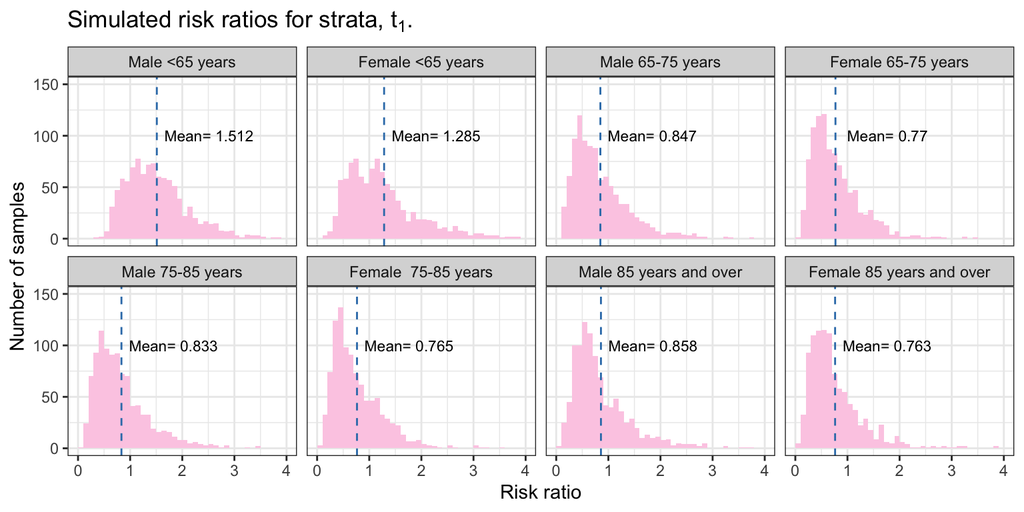

#### 3.3.2 Risk ratios for strata 1-8, $t_2$

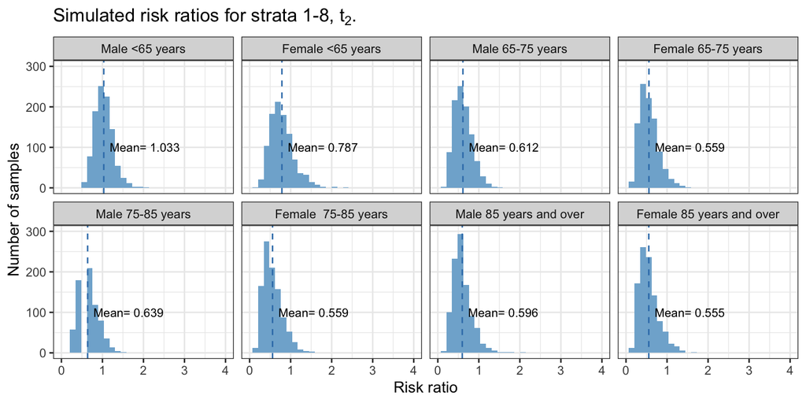

### 3.4 Pooled risk ratio

#### 3.4.1 Calibrated risk ratio at the end of the trial, for the whole trial

```
  The estimated calibrated risk ratio is 0.67 (95% confidence interval 0.51-0.85).
```

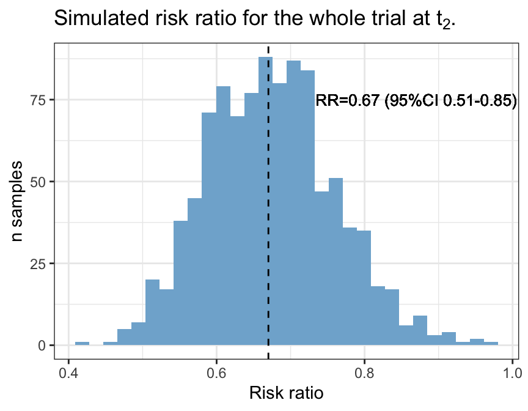

### 3.5 Competing event analysis: assuming no difference in non-stroke death between treatment and placebo arm

#### 3.5.1 Plots of outcomes

These plots show the cumulative incidence of a) recurrent stroke, b) death due to none-stroke cause and c) recurrent stroke, accounting for competing risk of death.

##### 3.5.1.1 Recurrent stroke outcome

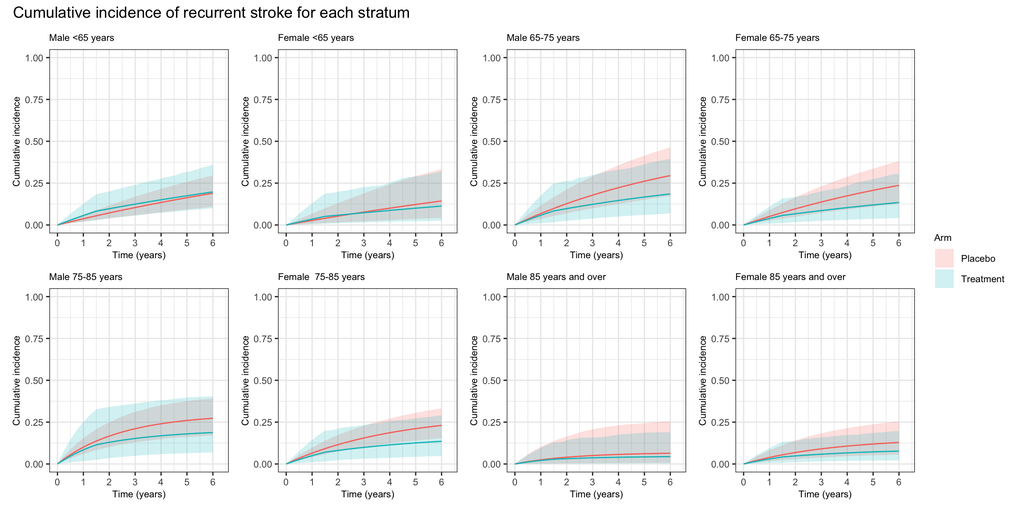

##### 3.5.1.2 Competing risk outcome

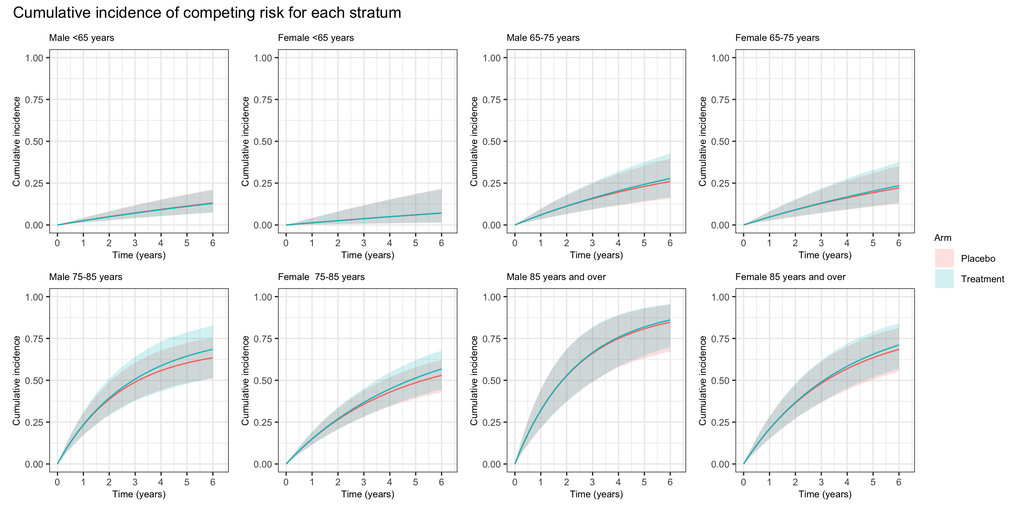

##### 3.5.1.3 Recurrent stroke, accounting for competing risk of non-stroke death

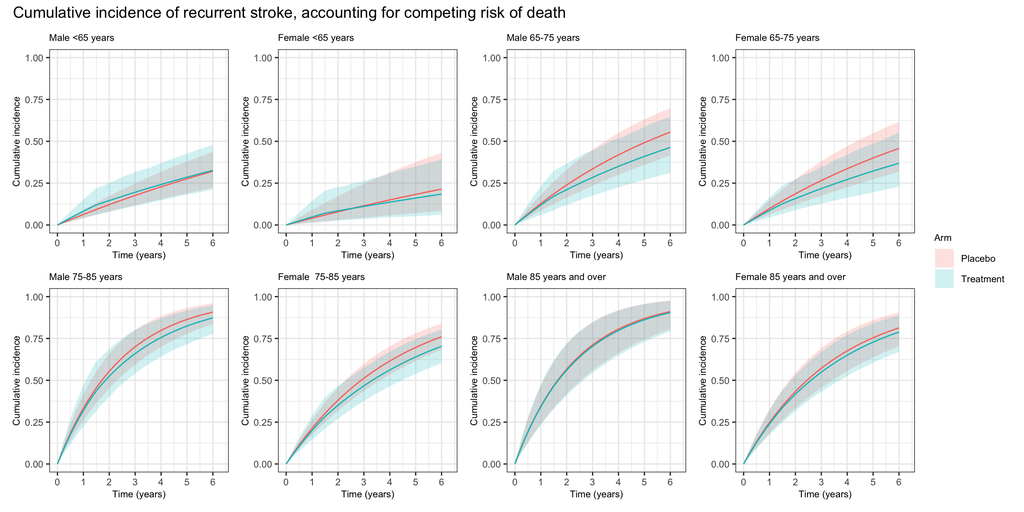

#### 3.5.2 Absolute risk reduction

These plots and tables show the absolute risk reduction for each stratum and overall, accounting for competing risk of death.

##### 3.5.2.1 Male <65 years

| Time (days) | Events in untreated (%) | Events in treated (%) | Absolute difference (%) | Lower CI (%) | Upper CI (%) |
| --- | --- | --- | --- | --- | --- |
| 0 | 0.0 | 0.0 | 0.0 | 0.0 | 0.0 |
| 90 | 1.6 | 2.1 | -0.5 | -2.1 | 0.3 |
| 365 | 6.3 | 8.2 | -1.9 | -7.8 | 1.3 |
| 1,825 | 27.6 | 28.5 | -1.0 | -9.5 | 5.1 |

##### 3.5.2.2 Female <65 years

| Time (days) | Events in untreated (%) | Events in treated (%) | Absolute difference (%) | Lower CI (%) | Upper CI (%) |
| --- | --- | --- | --- | --- | --- |
| 0 | 0.0 | 0.0 | 0.0 | 0.0 | 0.0 |
| 90 | 1.0 | 1.2 | -0.2 | -1.9 | 0.5 |
| 365 | 4.0 | 4.8 | -0.8 | -7.3 | 2.1 |
| 1,825 | 18.3 | 16.1 | 2.2 | -6.1 | 9.9 |

##### 3.5.2.3 Male 65-75 years

| Time (days) | Events in untreated (%) | Events in treated (%) | Absolute difference (%) | Lower CI (%) | Upper CI (%) |
| --- | --- | --- | --- | --- | --- |
| 0 | 0.0 | 0.0 | 0.0 | 0.0 | 0.0 |
| 90 | 3.3 | 3.1 | 0.2 | -2.7 | 1.7 |
| 365 | 12.8 | 11.8 | 1.0 | -9.3 | 6.3 |
| 1,825 | 49.1 | 40.9 | 8.2 | -3.0 | 18.2 |

##### 3.5.2.4 Female 65-75 years

| Time (days) | Events in untreated (%) | Events in treated (%) | Absolute difference (%) | Lower CI (%) | Upper CI (%) |
| --- | --- | --- | --- | --- | --- |
| 0 | 0.0 | 0.0 | 0.0 | 0.0 | 0.0 |
| 90 | 2.5 | 2.2 | 0.3 | -1.2 | 1.4 |
| 365 | 9.8 | 8.7 | 1.2 | -4.5 | 5.2 |
| 1,825 | 40.0 | 32.2 | 7.8 | -2.5 | 17.4 |

##### 3.5.2.5 Male 75-85 years

| Time (days) | Events in untreated (%) | Events in treated (%) | Absolute difference (%) | Lower CI (%) | Upper CI (%) |
| --- | --- | --- | --- | --- | --- |
| 0 | 0.0 | 0.0 | 0.0 | 0.0 | 0.0 |
| 90 | 9.5 | 9.1 | 0.4 | -3.9 | 2.6 |
| 365 | 33.3 | 31.9 | 1.4 | -10.8 | 8.0 |
| 1,825 | 86.3 | 82.4 | 3.9 | -1.8 | 9.5 |

##### 3.5.2.6 Female 75-85 years

| Time (days) | Events in untreated (%) | Events in treated (%) | Absolute difference (%) | Lower CI (%) | Upper CI (%) |
| --- | --- | --- | --- | --- | --- |
| 0 | 0.0 | 0.0 | 0.0 | 0.0 | 0.0 |
| 90 | 5.7 | 5.4 | 0.4 | -2.0 | 1.6 |
| 365 | 21.3 | 19.9 | 1.4 | -6.3 | 5.4 |
| 1,825 | 69.6 | 63.9 | 5.7 | -1.5 | 11.7 |

##### 3.5.2.7 Male 85 years and over

| Time (days) | Events in untreated (%) | Events in treated (%) | Absolute difference (%) | Lower CI (%) | Upper CI (%) |
| --- | --- | --- | --- | --- | --- |
| 0 | 0.0 | 0.0 | 0.0 | 0.0 | 0.0 |
| 90 | 10.0 | 9.9 | 0.1 | -1.0 | 1.2 |
| 365 | 34.4 | 34.1 | 0.3 | -2.9 | 3.6 |
| 1,825 | 86.9 | 86.1 | 0.8 | -0.2 | 3.8 |

##### 3.5.2.8 Female 85 years and over

| Time (days) | Events in untreated (%) | Events in treated (%) | Absolute difference (%) | Lower CI (%) | Upper CI (%) |
| --- | --- | --- | --- | --- | --- |
| 0 | 0.0 | 0.0 | 0.0 | 0.0 | 0.0 |
| 90 | 6.8 | 6.6 | 0.2 | -1.3 | 1.2 |
| 365 | 24.8 | 24.0 | 0.8 | -4.2 | 3.9 |
| 1,825 | 75.4 | 72.8 | 2.6 | -1.0 | 6.6 |

##### 3.5.2.9 Overall

| Time (days) | Absolute difference (%) | Lower CI (%) | Upper CI (%) |
| --- | --- | --- | --- |
| 0 | 0.0 | 0.0 | 0.0 |
| 90 | 0.1 | -0.7 | 0.7 |
| 365 | 0.5 | -2.3 | 2.4 |
| 1,825 | 3.9 | 1.1 | 6.4 |

#### 3.5.3 Plots

##### 3.5.3.1 Plot of ARR for each strata

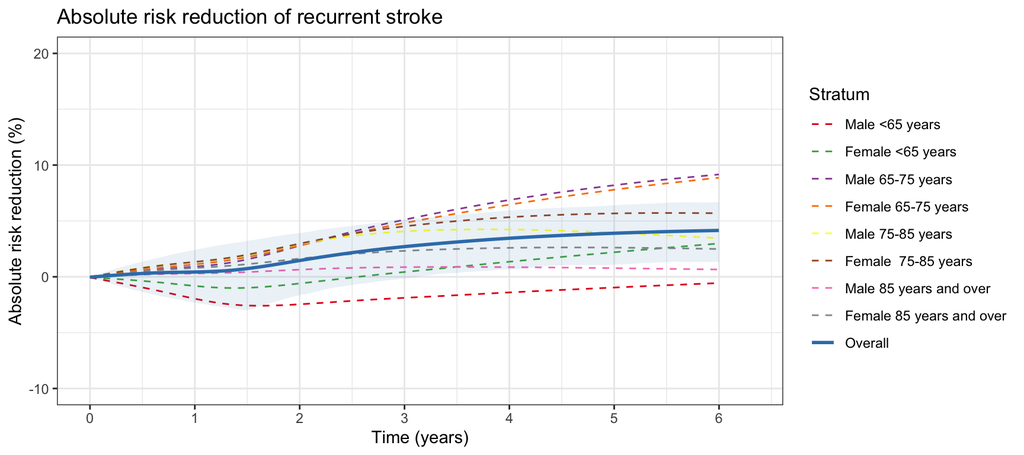

##### 3.5.3.2 Plot of ARR for each stratum separately

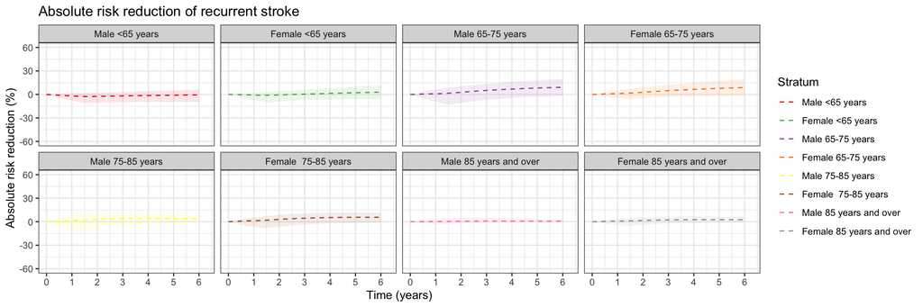

### 3.6 Competing event analysis: assuming difference in non-stroke death between treatment and placebo arm using hazard ratios from TRIDENT data.

#### 3.6.1 Hazard ratios from TRIDENT data

| Stratum | HR (95%CI) T1 | HR (95%CI) T2 |
| --- | --- | --- |
| Male <65 years | 0.21 (0.05-0.99) | 0.79 (0.4-1.56) |
| Female <65 years | 1.13 (0.16-8.03) | 0.56 (0.1-3.05) |
| Male 65-75 years | 0.64 (0.21-1.95) | 1.1 (0.54-2.26) |
| Female 65-75 years | 0.93 (0.33-2.66) | 0.9 (0.43-1.9) |
| Male 75-85 years | 0.64 (0.21-1.95) | 1.1 (0.54-2.26) |
| Female 75-85 years | 0.93 (0.33-2.66) | 0.9 (0.43-1.9) |
| Male 85 years and over | 0.64 (0.21-1.95) | 1.1 (0.54-2.26) |
| Female 85 years and over | 0.93 (0.33-2.66) | 0.9 (0.43-1.9) |

#### 3.6.2 Event rates for competing risk using hazard ratios from TRIDENT

| Stratum | Rate of non-stroke death per 100py (95%CI) | Events per 100py, treated t1 | Events per 100py, treated t2 |
| --- | --- | --- | --- |
| Male <65 years | 2.52 (1.43-4.44) | 0.54 (0.11 - 2.66) | 2.03 (0.85 - 4.63) |
| Female <65 years | 1.08 (0.27-4.31) | 1.16 (0.11 - 11.83) | 0.58 (0.06 - 5.31) |
| Male 65-75 years | 6.19 (3.6-10.67) | 3.85 (1.08 - 13.35) | 6.71 (2.83 - 16.32) |
| Female 65-75 years | 4.8 (2.66-8.67) | 4.48 (1.36 - 13.96) | 4.4 (1.65 - 11.18) |
| Male 75-85 years | 27.92 (20.23-38.54) | 18.33 (5.66 - 56.19) | 30.64 (13.87 - 66.17) |
| Female 75-85 years | 16.6 (12.65-21.79) | 15.71 (5.39 - 48.37) | 14.81 (6.51 - 32.78) |
| Male 85 years and over | 38.84 (25.06-60.2) | 24.46 (7.09 - 86.54) | 41.59 (20.58 - 94.47) |
| Female 85 years and over | 23.47 (16.93-32.54) | 21.46 (7.14 - 63.79) | 21.04 (9.67 - 47.61) |

#### 3.6.3 Plots of outcomes

These plots show the cumulative incidence of a) recurrent stroke, b) death due to none-stroke cause and c) recurrent stroke, accounting for competing risk of death.

##### 3.6.3.1 Recurrent stroke outcome

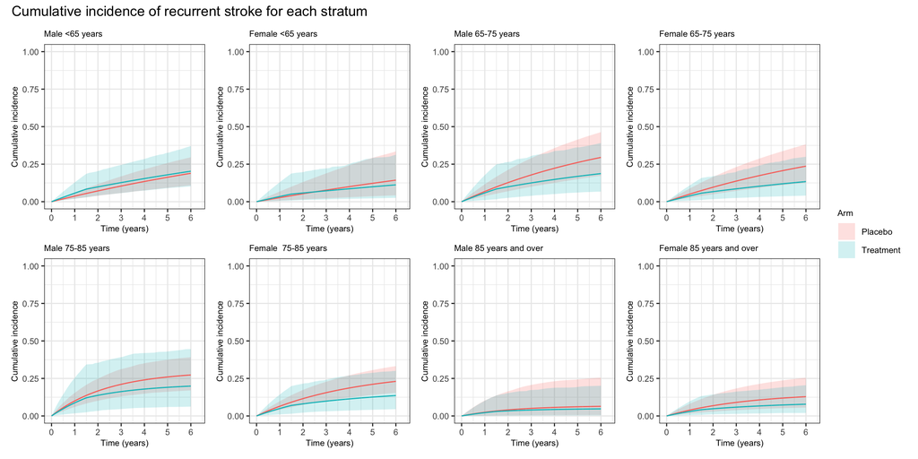

##### 3.6.3.2 Competing outcome (none-stroke death)

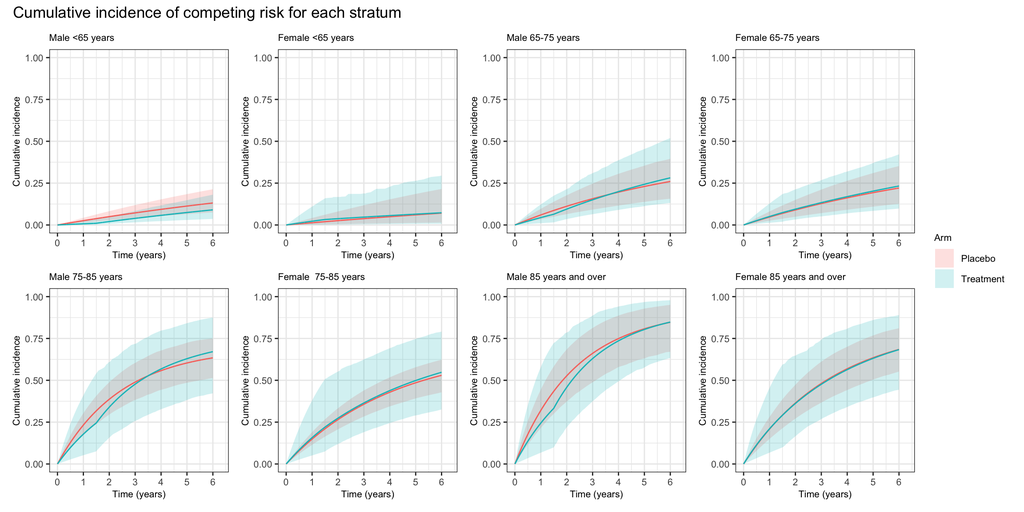

##### 3.6.3.3 Recurrent stroke, accounting for competing risk of none-stroke death

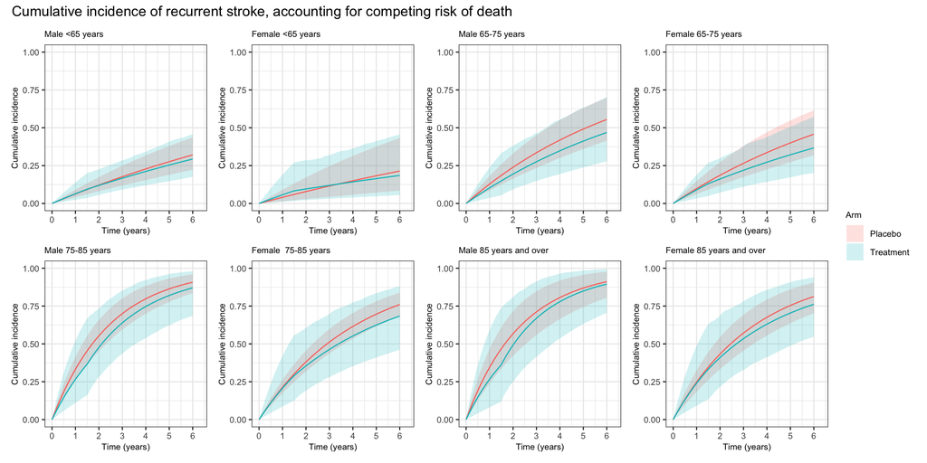

#### 3.6.4 Absolute risk reduction

These plots and tables show the absolute risk reduction for each stratum and overall, accounting for competing risk of death.

##### 3.6.4.1 Male <65 years

| Time (days) | Events in untreated (%) | Events in treated (%) | Absolute difference (%) | Lower CI (%) | Upper CI (%) |
| --- | --- | --- | --- | --- | --- |
| 0 | 0.0 | 0.0 | 0.0 | 0.0 | 0.0 |
| 90 | 1.6 | 1.6 | 0.0 | -1.7 | 0.9 |
| 365 | 6.3 | 6.4 | -0.1 | -6.2 | 3.5 |
| 1,825 | 27.6 | 25.4 | 2.2 | -7.5 | 10.2 |

##### 3.6.4.2 Female <65 years

| Time (days) | Events in untreated (%) | Events in treated (%) | Absolute difference (%) | Lower CI (%) | Upper CI (%) |
| --- | --- | --- | --- | --- | --- |
| 0 | 0.0 | 0.0 | 0.0 | 0.0 | 0.0 |
| 90 | 1.0 | 1.5 | -0.5 | -3.3 | 0.7 |
| 365 | 4.0 | 5.7 | -1.7 | -12.2 | 2.7 |
| 1,825 | 18.3 | 16.4 | 1.9 | -13.3 | 12.5 |

##### 3.6.4.3 Male 65-75 years

| Time (days) | Events in untreated (%) | Events in treated (%) | Absolute difference (%) | Lower CI (%) | Upper CI (%) |
| --- | --- | --- | --- | --- | --- |
| 0 | 0.0 | 0.0 | 0.0 | 0.0 | 0.0 |
| 90 | 3.3 | 2.7 | 0.7 | -2.5 | 2.6 |
| 365 | 12.8 | 10.3 | 2.5 | -8.8 | 9.6 |
| 1,825 | 49.1 | 41.2 | 8.0 | -8.5 | 23.0 |

##### 3.6.4.4 Female 65-75 years

| Time (days) | Events in untreated (%) | Events in treated (%) | Absolute difference (%) | Lower CI (%) | Upper CI (%) |
| --- | --- | --- | --- | --- | --- |
| 0 | 0.0 | 0.0 | 0.0 | 0.0 | 0.0 |
| 90 | 2.5 | 2.3 | 0.2 | -2.3 | 1.8 |
| 365 | 9.8 | 9.0 | 0.9 | -8.2 | 6.9 |
| 1,825 | 40.0 | 32.1 | 7.8 | -7.0 | 21.1 |

##### 3.6.4.5 Male 75-85 years

| Time (days) | Events in untreated (%) | Events in treated (%) | Absolute difference (%) | Lower CI (%) | Upper CI (%) |
| --- | --- | --- | --- | --- | --- |
| 0 | 0.0 | 0.0 | 0.0 | 0.0 | 0.0 |
| 90 | 9.5 | 7.5 | 2.0 | -6.6 | 6.9 |
| 365 | 33.3 | 26.6 | 6.7 | -17.6 | 22.5 |
| 1,825 | 86.3 | 82.0 | 4.3 | -8.3 | 20.8 |

##### 3.6.4.6 Female 75-85 years

| Time (days) | Events in untreated (%) | Events in treated (%) | Absolute difference (%) | Lower CI (%) | Upper CI (%) |
| --- | --- | --- | --- | --- | --- |
| 0 | 0.0 | 0.0 | 0.0 | 0.0 | 0.0 |
| 90 | 5.7 | 5.7 | 0.1 | -6.2 | 3.6 |
| 365 | 21.3 | 20.7 | 0.6 | -19.2 | 12.7 |
| 1,825 | 69.6 | 62.4 | 7.2 | -12.7 | 26.2 |

##### 3.6.4.7 Male 85 years and over

| Time (days) | Events in untreated (%) | Events in treated (%) | Absolute difference (%) | Lower CI (%) | Upper CI (%) |
| --- | --- | --- | --- | --- | --- |
| 0 | 0.0 | 0.0 | 0.0 | 0.0 | 0.0 |
| 90 | 10.0 | 7.7 | 2.2 | -8.8 | 8.2 |
| 365 | 34.4 | 26.6 | 7.8 | -22.3 | 26.2 |
| 1,825 | 86.9 | 84.9 | 2.0 | -10.3 | 19.1 |

##### 3.6.4.8 Female 85 years and over

| Time (days) | Events in untreated (%) | Events in treated (%) | Absolute difference (%) | Lower CI (%) | Upper CI (%) |
| --- | --- | --- | --- | --- | --- |
| 0 | 0.0 | 0.0 | 0.0 | 0.0 | 0.0 |
| 90 | 6.8 | 6.7 | 0.1 | -7.8 | 4.3 |
| 365 | 24.8 | 24.0 | 0.8 | -22.0 | 14.7 |
| 1,825 | 75.4 | 70.4 | 5.0 | -12.6 | 24.1 |

##### 3.6.4.9 Overall

| Time (days) | Absolute difference (%) | Lower CI (%) | Upper CI (%) |
| --- | --- | --- | --- |
| 0 | 0.0 | 0.0 | 0.0 |
| 90 | 0.5 | -1.6 | 2.0 |
| 365 | 1.9 | -4.2 | 6.7 |
| 1,825 | 5.2 | -0.4 | 10.9 |

#### 3.6.5 Plots

##### 3.6.5.1 Plot of ARR for each strata

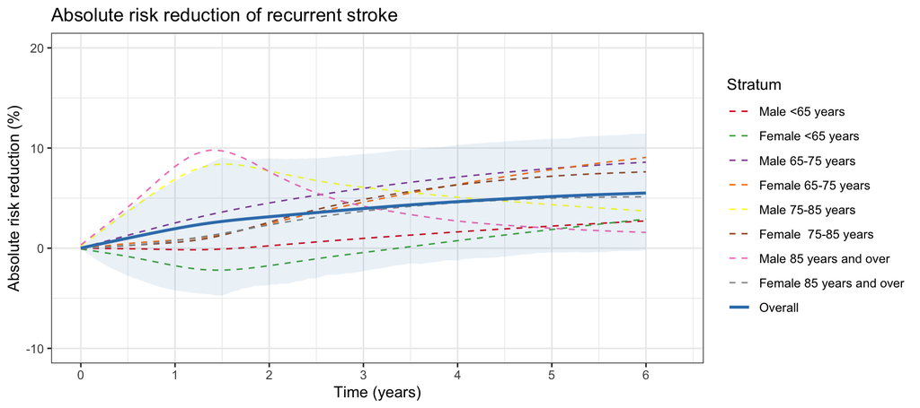

##### 3.6.5.2 Plot of ARR for each stratum separately

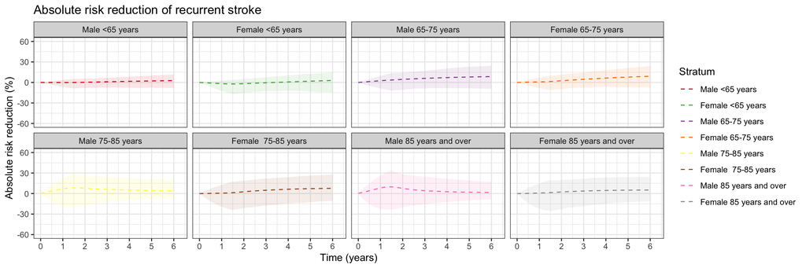

### 3.7 ARR with no competing events

#### 3.7.1 Plots of outcomes

These plots show the cumulative incidence of a) recurrent stroke, b) death due to none-stroke cause and c) recurrent stroke, accounting for competing risk of death.

##### 3.7.1.1 Recurrent stroke outcome

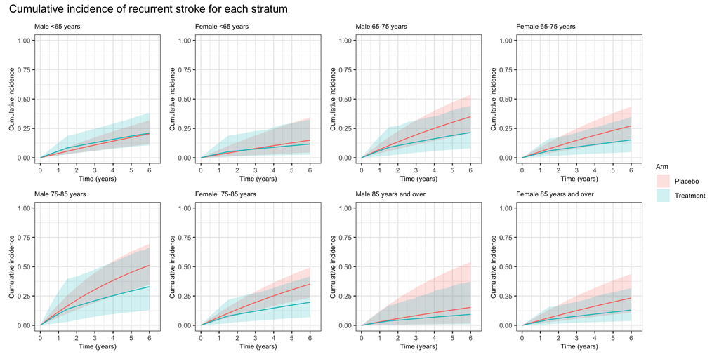

##### 3.7.1.2 Competing outcome (none-stroke death)

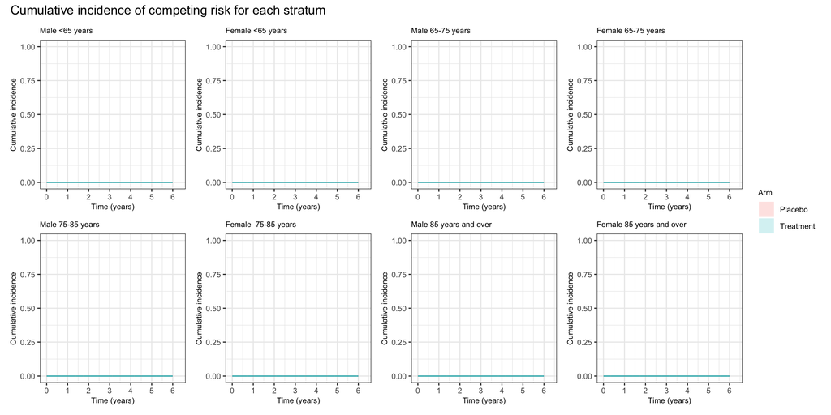

##### 3.7.1.3 Recurrent stroke, accounting for competing risk of none-stroke death

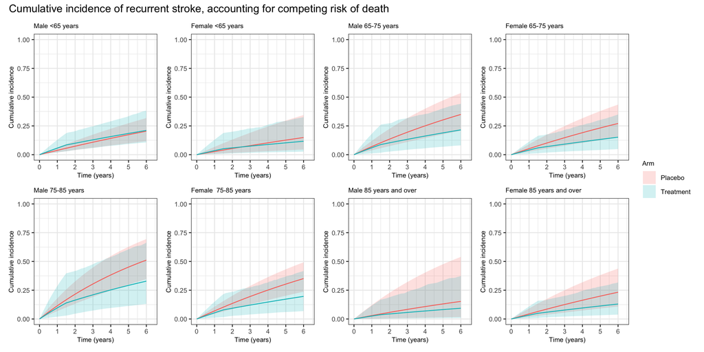

#### 3.7.2 Absolute risk reduction

These plots and tables show the absolute risk reduction for each stratum and overall, accounting for competing risk of death.

##### 3.7.2.1 Male <65 years

| Time (days) | Events in untreated (%) | Events in treated (%) | Absolute difference (%) | Lower CI (%) | Upper CI (%) |
| --- | --- | --- | --- | --- | --- |
| 0 | 0.0 | 0.0 | 0.0 | 0.0 | 0.0 |
| 90 | 0.9 | 1.4 | -0.5 | -2.2 | 0.3 |
| 365 | 3.8 | 5.7 | -2.0 | -8.0 | 1.3 |
| 1,825 | 17.3 | 18.4 | -1.1 | -11.3 | 6.0 |

##### 3.7.2.2 Female <65 years

| Time (days) | Events in untreated (%) | Events in treated (%) | Absolute difference (%) | Lower CI (%) | Upper CI (%) |
| --- | --- | --- | --- | --- | --- |
| 0 | 0.0 | 0.0 | 0.0 | 0.0 | 0.0 |
| 90 | 0.7 | 0.9 | -0.2 | -1.9 | 0.6 |
| 365 | 2.7 | 3.5 | -0.8 | -7.3 | 2.2 |
| 1,825 | 12.6 | 10.3 | 2.4 | -6.4 | 10.5 |

##### 3.7.2.3 Male 65-75 years

| Time (days) | Events in untreated (%) | Events in treated (%) | Absolute difference (%) | Lower CI (%) | Upper CI (%) |
| --- | --- | --- | --- | --- | --- |
| 0 | 0.0 | 0.0 | 0.0 | 0.0 | 0.0 |
| 90 | 1.8 | 1.5 | 0.2 | -2.7 | 1.7 |
| 365 | 7.0 | 6.0 | 1.0 | -9.8 | 6.8 |
| 1,825 | 30.2 | 18.9 | 11.3 | -4.3 | 25.5 |

##### 3.7.2.4 Female 65-75 years

| Time (days) | Events in untreated (%) | Events in treated (%) | Absolute difference (%) | Lower CI (%) | Upper CI (%) |
| --- | --- | --- | --- | --- | --- |
| 0 | 0.0 | 0.0 | 0.0 | 0.0 | 0.0 |
| 90 | 1.3 | 1.0 | 0.3 | -1.2 | 1.4 |
| 365 | 5.2 | 4.0 | 1.2 | -4.7 | 5.5 |
| 1,825 | 23.2 | 13.2 | 10.0 | -3.1 | 22.1 |

##### 3.7.2.5 Male 75-85 years

| Time (days) | Events in untreated (%) | Events in treated (%) | Absolute difference (%) | Lower CI (%) | Upper CI (%) |
| --- | --- | --- | --- | --- | --- |
| 0 | 0.0 | 0.0 | 0.0 | 0.0 | 0.0 |
| 90 | 3.0 | 2.5 | 0.4 | -4.2 | 2.8 |
| 365 | 11.5 | 9.7 | 1.8 | -14.7 | 10.4 |
| 1,825 | 45.1 | 29.2 | 15.9 | -7.3 | 35.0 |

##### 3.7.2.6 Female 75-85 years

| Time (days) | Events in untreated (%) | Events in treated (%) | Absolute difference (%) | Lower CI (%) | Upper CI (%) |
| --- | --- | --- | --- | --- | --- |
| 0 | 0.0 | 0.0 | 0.0 | 0.0 | 0.0 |
| 90 | 1.8 | 1.4 | 0.4 | -2.0 | 1.7 |
| 365 | 7.0 | 5.4 | 1.6 | -7.6 | 6.5 |
| 1,825 | 30.3 | 17.2 | 13.1 | -3.3 | 26.7 |

##### 3.7.2.7 Male 85 years and over

| Time (days) | Events in untreated (%) | Events in treated (%) | Absolute difference (%) | Lower CI (%) | Upper CI (%) |
| --- | --- | --- | --- | --- | --- |
| 0 | 0.0 | 0.0 | 0.0 | 0.0 | 0.0 |
| 90 | 0.8 | 0.6 | 0.1 | -1.2 | 1.3 |
| 365 | 3.0 | 2.5 | 0.4 | -4.5 | 5.2 |
| 1,825 | 13.1 | 8.2 | 4.9 | -1.9 | 19.6 |

##### 3.7.2.8 Female 85 years and over

| Time (days) | Events in untreated (%) | Events in treated (%) | Absolute difference (%) | Lower CI (%) | Upper CI (%) |
| --- | --- | --- | --- | --- | --- |
| 0 | 0.0 | 0.0 | 0.0 | 0.0 | 0.0 |
| 90 | 1.1 | 0.8 | 0.3 | -1.4 | 1.3 |
| 365 | 4.4 | 3.4 | 1.0 | -5.2 | 4.9 |
| 1,825 | 19.9 | 11.3 | 8.5 | -3.0 | 21.3 |

##### 3.7.2.9 Overall

| Time (days) | Absolute difference (%) | Lower CI (%) | Upper CI (%) |
| --- | --- | --- | --- |
| 0 | 0.0 | 0.0 | 0.0 |
| 90 | 0.2 | -0.8 | 0.8 |
| 365 | 0.6 | -2.7 | 2.9 |
| 1,825 | 8.8 | 3.3 | 13.8 |

#### 3.7.3 Plots

##### 3.7.3.1 Plot of ARR for each strata

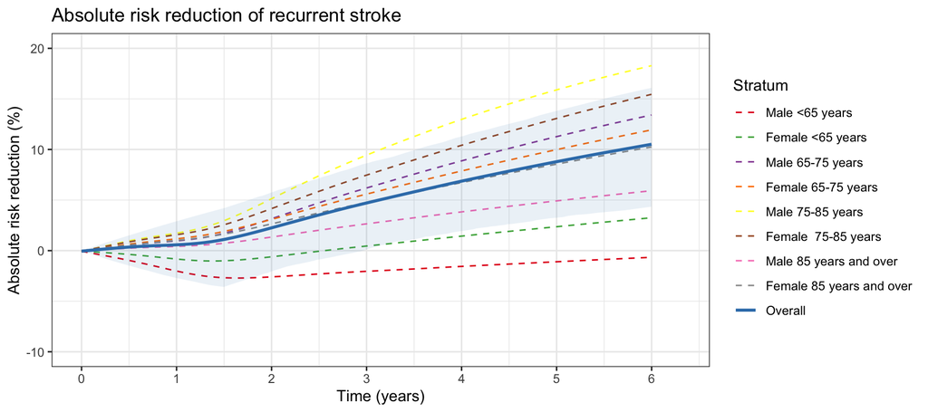

##### 3.7.3.2 Plot of ARR for each stratum separately

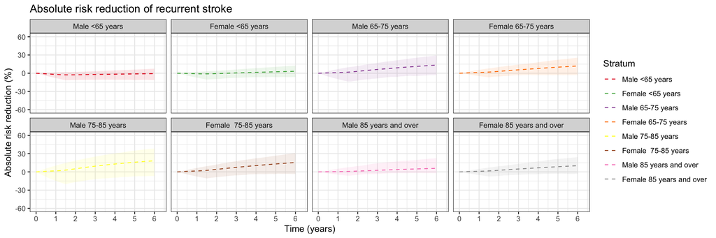

### 3.8 Combine competing risk plots

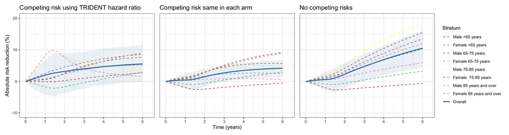

### 3.9 Alternative combined plot for competing risks

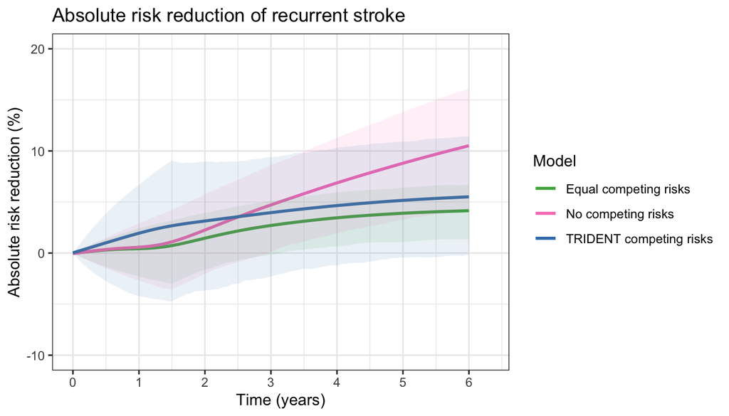

### 3.10 How reasonable is assumption TRIDENT drug might reduce all-cause death?

LATCH recorded causes of death, which have been categorised as vascular and non-vascular. Defined as per Linxin Li, Lancet Neurol. 2021 Jun;20(6):437–447. doi: 10.1016/S1474-4422(21)00075-2: “We defined vascular death as death within 30 days following and due to recurrent symptomatic ICH, extracranial haemorrhage, ischaemic stroke, myocardial infarction, peripheral artery occlusion, mesenteric ischaemia, central retinal arterial occlusion, symptomatic deep vein thrombosis, symptomatic pulmonary embolism, sudden cardiac death (with symptoms suggestive of myocardial infarction or evidence of arrhythmia), symptomatic stroke of uncertain subtype, or revascularisation procedures.”

Among those who did not experience the primary outcome (recurrent stroke of any cause) the causes of death were as follows:

| Var1 | Freq |
| --- | --- |
| Index ICH | 19 |
| Non vascular death | 140 |
| Vascular death beyond 30d of vascular event | 15 |
| Vascular death within 30d of vascular event | 42 |

## 4 Appendix

We pool the risk ratio at $t_1$, to find the calibrated relative risk after 18 months.

```
The estimated calibrated risk ratio is 0.95 (95% confidence interval 0.61-1.39)
```